# Tugas 1 MPDW

Davina Rachmadyanti

2023-09-03

```r
knitr::opts_chunk$set(echo = TRUE)
```

Persiapan library

```r
library("forecast")
```

```r
library("graphics")
library("TTR")
library("TSA")
library("rio")
```

Import data dari github

```r
input <- import("https://raw.githubusercontent.com/davinarachmadyanti/mpdw/main/Data/Data.csv")
```

Eksplorasi awal data

```r
str(input)
```

```
## 'data.frame':    158 obs. of  2 variables:
##  $ Date : IDate, format: "2020-08-31" "2020-09-07" ...
##  $ Close: int  2860 2810 2890 2690 2680 2730 2750 2630 2620 2830 ...
```

```r
dim(input)
```

```
## [1] 158   2
```

Mengubah data agar terbaca sebagai data deret waktu dengan fungsi `ts()`

```r
data.ts <- ts(input$Close)
data.ts
```

```
## Time Series:
## Start = 1
## End = 158
## Frequency = 1
##   [1] 2860 2810 2890 2690 2680 2730 2750 2630 2620 2830 2990 3220 3460 3250 3280
##  [16] 3510 3320 3310 3570 3480 3390 3110 3290 3190 3210 3490 3320 3450 3440 3490
##  [31] 3390 3360 3360 3310 3200 3190 3180 3270 3270 3500 3470 3350 3250 3070 3160
##  [46] 3170 3170 3240 3320 3300 3400 3320 3390 3330 3530 3560 3660 3800 3810 3870
##  [61] 3800 3770 3600 3900 4010 4070 4150 4100 4110 4040 4170 4190 4330 4260 4230
##  [76] 4450 4400 4340 4400 4590 4540 4520 4580 4580 4680 4620 4620 4620 4260 4170
##  [91] 4300 4310 4020 4120 4150 4020 4010 4150 4230 4230 4650 4550 4600 4490 4600
## [106] 4600 4410 4380 4460 4350 4290 4360 4450 4210 4150 4010 4030 4000 3650 3680
## [121] 3780 3750 3710 3780 3870 3960 3880 3800 3760 4040 3900 4010 4050 4070 4060
## [136] 4250 4340 4270 4250 4170 3980 4020 4130 4040 4150 3970 3950 4000 3960 3930
## [151] 3860 3720 3690 3810 3760 3720 3720 3720
```

```r
summary(data.ts)
```

```
##    Min. 1st Qu.  Median    Mean 3rd Qu.    Max.
##    2620    3368    3870    3803    4185    4680
```

Membuat plot data deret waktu

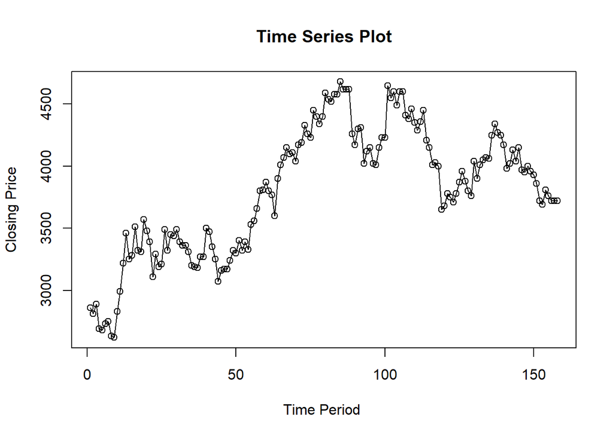

```r
ts.plot(data.ts, xlab="Time Period ", ylab="Closing Price",
        main = "Time Series Plot")
points(data.ts)
```

Pembagian Data

Pembagian data latih (training) dan data uji (testing) dilakukan dengan perbandingan 80% data latih dan 20% data uji.

```r
#membagi data latih dan data uji
training_data <- input[1:127,]
testing_data <- input[128:158,]
train_data.ts <- ts(training_data$Close)
test_data.ts <- ts(testing_data$Close)
```

Eksplorasi Data

Eksplorasi data dilakukan pada keseluruhan data, data latih serta data uji menggunakan plot data deret waktu.

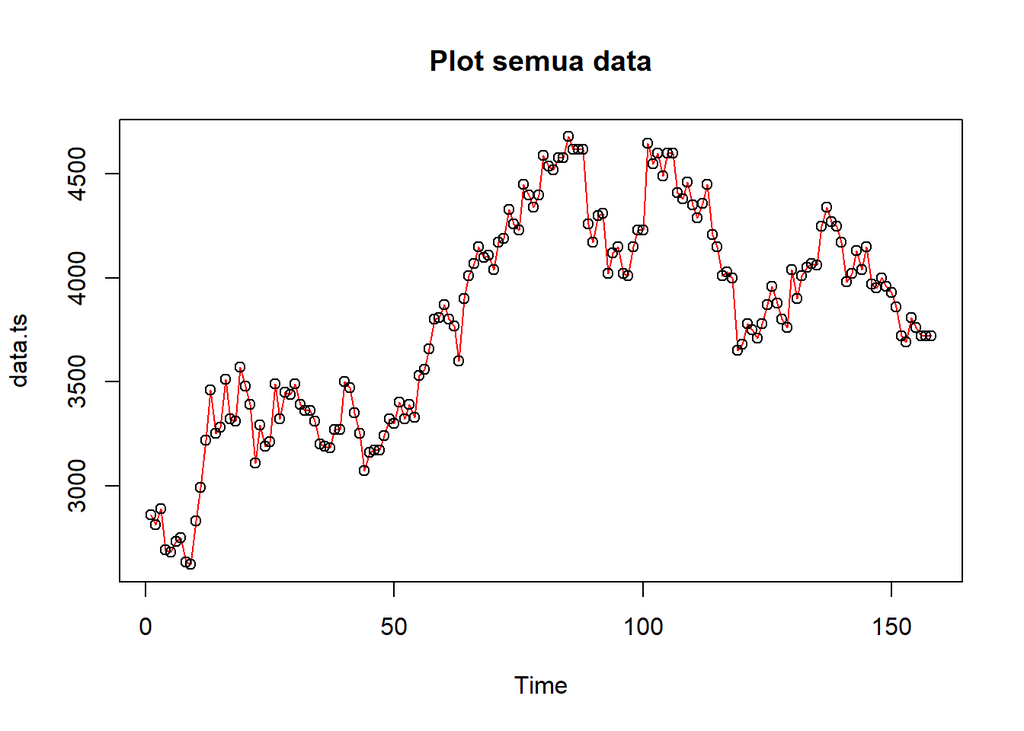

```r
#eksplorasi keseluruhan data
plot(data.ts, col="red",main="Plot semua data")
points(data.ts)
```

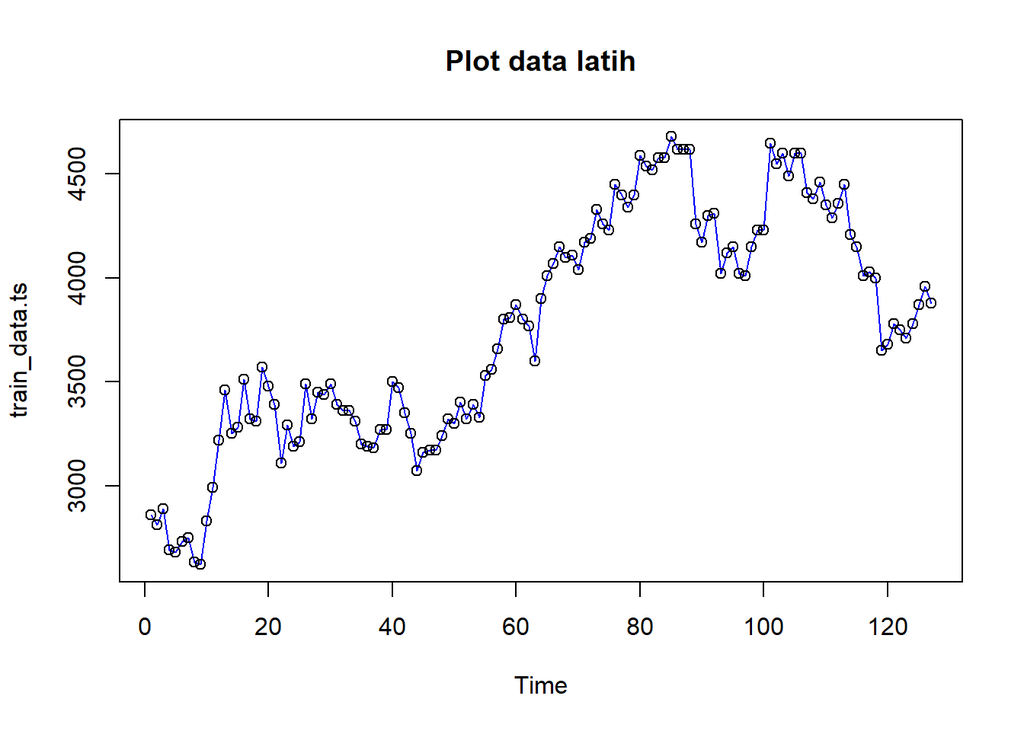

```r
#eksplorasi data latih
plot(train_data.ts, col="blue",main="Plot data latih")
points(train_data.ts)
```

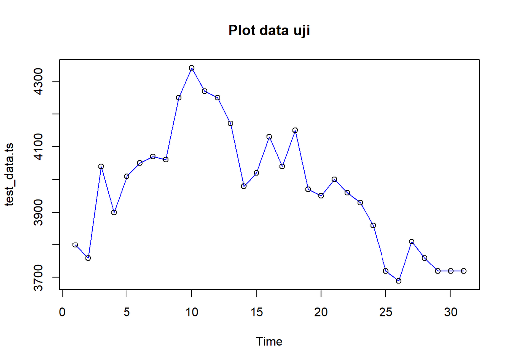

```r
#eksplorasi data uji
plot(test_data.ts, col="blue",main="Plot data uji")
points(test_data.ts)
```

Plot data latih cenderung menunjukkan pola data trend, namun pada plot data uji terlihat bahwa nilai mengalami penurunan di periode-periode akhir.

Eksplorasi data juga dapat dilakukan menggunakan package ggplot2 dengan terlebih dahulu memanggil library package ggplot2.

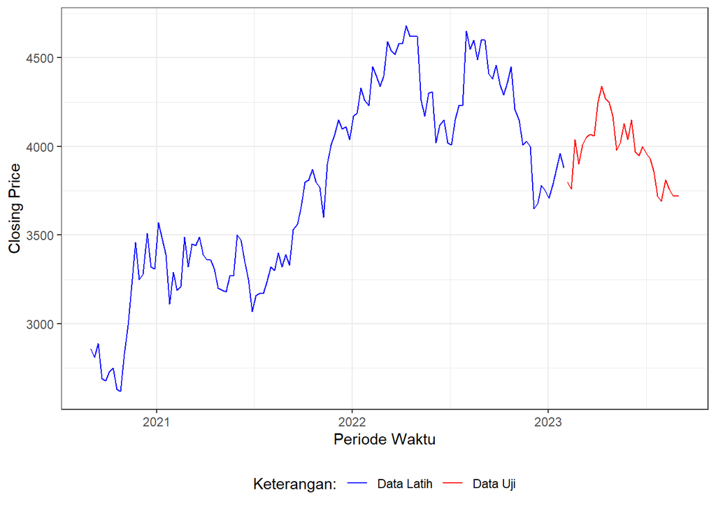

```r
#Eksplorasi dengan GGPLOT
library(ggplot2)
ggplot() +
  geom_line(data = training_data, aes(x = Date, y = Close, col = "Data Latih")) +
  geom_line(data = testing_data, aes(x = Date, y = Close, col = "Data Uji")) +
  labs(x = "Periode Waktu", y = "Closing Price", color = "Legend") +
  scale_colour_manual(name="Keterangan:", breaks = c("Data Latih", "Data Uji"),
                      values = c("blue", "red")) +
  theme_bw() + theme(legend.position = "bottom",
                     plot.caption = element_text(hjust=0.5, size=12))
```

Single Moving Average

Ide dasar dari Single Moving Average (SMA) adalah data suatu periode dipengaruhi oleh data periode sebelumnya. Metode pemulusan ini cocok digunakan untuk pola data stasioner atau konstan. Prinsip dasar metode pemulusan ini adalah data pemulusan pada periode ke-t merupakan rata rata dari m buah data pada periode ke-t hingga periode ke (t-m+1). Data pemulusan pada periode ke-t selanjutnya digunakan sebagai nilai peramalan pada periode ke t+1

Pemulusan menggunakan metode SMA dilakukan dengan fungsi `SMA()`. Dalam hal ini akan dilakukan pemulusan dengan parameter `m=2`.

```r
data.sma<-SMA(train_data.ts, n=2)
data.sma
```

```
## Time Series:
## Start = 1
## End = 127
## Frequency = 1
##   [1]   NA 2835 2850 2790 2685 2705 2740 2690 2625 2725 2910 3105 3340 3355 3265
##  [16] 3395 3415 3315 3440 3525 3435 3250 3200 3240 3200 3350 3405 3385 3445 3465
##  [31] 3440 3375 3360 3335 3255 3195 3185 3225 3270 3385 3485 3410 3300 3160 3115
##  [46] 3165 3170 3205 3280 3310 3350 3360 3355 3360 3430 3545 3610 3730 3805 3840
##  [61] 3835 3785 3685 3750 3955 4040 4110 4125 4105 4075 4105 4180 4260 4295 4245
##  [76] 4340 4425 4370 4370 4495 4565 4530 4550 4580 4630 4650 4620 4620 4440 4215
##  [91] 4235 4305 4165 4070 4135 4085 4015 4080 4190 4230 4440 4600 4575 4545 4545
## [106] 4600 4505 4395 4420 4405 4320 4325 4405 4330 4180 4080 4020 4015 3825 3665
## [121] 3730 3765 3730 3745 3825 3915 3920
```

Data pemulusan pada periode ke-t selanjutnya digunakan sebagai nilai peramalan pada periode ke t+1 sehingga hasil peramalan 1 periode kedepan adalah sebagai berikut.

```r
data.ramal<-c(NA,data.sma)
data.ramal #forecast 1 periode ke depan
```

```
##   [1]   NA   NA 2835 2850 2790 2685 2705 2740 2690 2625 2725 2910 3105 3340 3355
##  [16] 3265 3395 3415 3315 3440 3525 3435 3250 3200 3240 3200 3350 3405 3385 3445
##  [31] 3465 3440 3375 3360 3335 3255 3195 3185 3225 3270 3385 3485 3410 3300 3160
##  [46] 3115 3165 3170 3205 3280 3310 3350 3360 3355 3360 3430 3545 3610 3730 3805
##  [61] 3840 3835 3785 3685 3750 3955 4040 4110 4125 4105 4075 4105 4180 4260 4295
##  [76] 4245 4340 4425 4370 4370 4495 4565 4530 4550 4580 4630 4650 4620 4620 4440
##  [91] 4215 4235 4305 4165 4070 4135 4085 4015 4080 4190 4230 4440 4600 4575 4545
## [106] 4545 4600 4505 4395 4420 4405 4320 4325 4405 4330 4180 4080 4020 4015 3825
## [121] 3665 3730 3765 3730 3745 3825 3915 3920
```

Selanjutnya akan dilakukan peramalan sejumlah data uji yaitu 31 periode. Pada metode SMA, hasil peramalan 31 periode ke depan akan bernilai sama dengan hasil peramalan 1 periode kedepan. Dalam hal ini akan dilakukan pengguabungan data aktual train, data hasil pemulusan dan data hasil ramalan 31 periode kedepan.

```r
data.gab<-cbind(aktual=c(train_data.ts,rep(NA,31)),pemulusan=c(data.sma,rep(NA,31)),ramalan=c(data.ramal,rep(data.ramal[length(data.ramal)],30)))
data.gab #forecast 31 periode ke depan
```

```
##        aktual pemulusan ramalan
##   [1,]   2860        NA      NA
##   [2,]   2810      2835      NA
##   [3,]   2890      2850    2835
##   [4,]   2690      2790    2850
##   [5,]   2680      2685    2790
##   [6,]   2730      2705    2685
##   [7,]   2750      2740    2705
##   [8,]   2630      2690    2740
##   [9,]   2620      2625    2690
##  [10,]   2830      2725    2625
##  [11,]   2990      2910    2725
##  [12,]   3220      3105    2910
##  [13,]   3460      3340    3105
##  [14,]   3250      3355    3340
```

[output cut: 144 more lines]

Adapun plot data deret waktu dari hasil peramalan yang dilakukan adalah sebagai berikut.

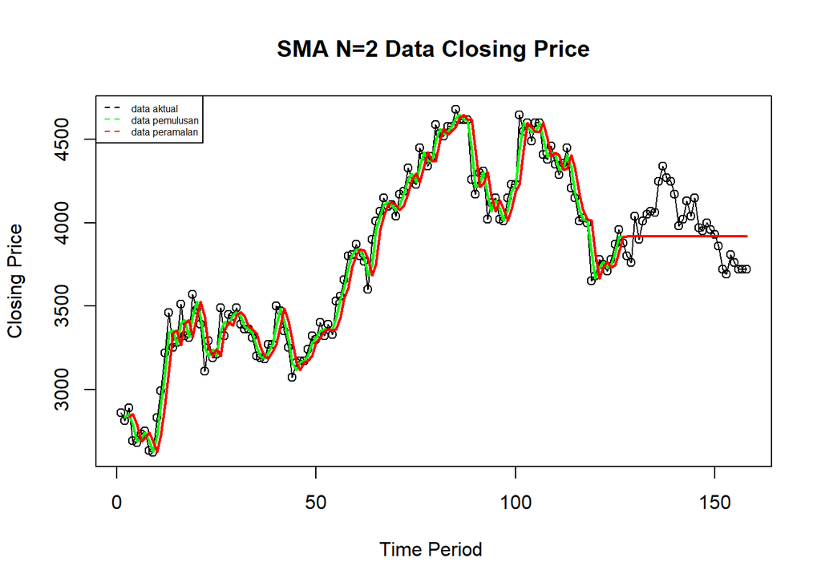

```r
ts.plot(data.ts, xlab="Time Period ", ylab="Closing Price", main= "SMA N=2 Data Closing Price")
points(data.ts)
lines(data.gab[,2],col="green",lwd=2)
lines(data.gab[,3],col="red",lwd=2)
legend("topleft",c("data aktual","data pemulusan","data peramalan"), lty=8, col=c("black","green","red"), cex=0.5)
```

Selanjutnya perhitungan akurasi dilakukan dengan ukuran akurasi *Sum Squares Error* (SSE), *Mean Square Error* (MSE) dan *Mean Absolute Percentage Error* (MAPE). Perhitungan akurasi dilakukan baik pada data latih maupun pada data uji.

```r
#Menghitung nilai keakuratan data latih
error_train.sma = train_data.ts-data.ramal[1:length(train_data.ts)]
SSE_train.sma = sum(error_train.sma[5:length(train_data.ts)]^2)
MSE_train.sma = mean(error_train.sma[5:length(train_data.ts)]^2)
MAPE_train.sma = mean(abs((error_train.sma[5:length(train_data.ts)]/train_data.ts[5:length(train_data.ts)])*100))

akurasi_train.sma <- matrix(c(SSE_train.sma, MSE_train.sma, MAPE_train.sma))
row.names(akurasi_train.sma)<- c("SSE", "MSE", "MAPE")
colnames(akurasi_train.sma) <- c("Akurasi m = 2")
akurasi_train.sma
```

```
##      Akurasi m = 2
## SSE   2.401725e+06
## MSE   1.952622e+04
## MAPE  2.895774e+00
```

Dalam hal ini nilai MAPE data latih pada metode pemulusan SMA kurang dari 10%, nilai ini dapat dikategorikan sebagai nilai akurasi yang sangat baik. Selanjutnya dilakukan perhitungan nilai MAPE data uji pada metde pemulusan SMA.

```r
#Menghitung nilai keakuratan data uji
error_test.sma = test_data.ts-data.gab[128:158,3]
SSE_test.sma = sum(error_test.sma^2)
MSE_test.sma = mean(error_test.sma^2)
MAPE_test.sma = mean(abs((error_test.sma/test_data.ts*100)))

akurasi_test.sma <- matrix(c(SSE_test.sma, MSE_test.sma, MAPE_test.sma))
row.names(akurasi_test.sma)<- c("SSE", "MSE", "MAPE")
colnames(akurasi_test.sma) <- c("Akurasi m = 2")
akurasi_test.sma
```

```
##      Akurasi m = 2
## SSE   1.091800e+06
## MSE   3.521935e+04
## MAPE  3.941750e+00
```

Perhitungan akurasi menggunakan data latih menghasilkan nilai MAPE yang kurang dari 10% sehingga nilai akurasi ini dapat dikategorikan sebagai sangat baik.

Single Exponential Smoothing

Metode Exponential Smoothing adalah metode pemulusan dengan melakukan pembobotan menurun secara eksponensial. Nilai yang lebih baru diberi bobot yang lebih besar dari nilai terdahulu. Terdapat satu atau lebih parameter pemulusan yang ditentukan secara eksplisit, dan hasil pemilihan parameter tersebut akan menentukan bobot yang akan diberikan pada nilai pengamatan. Ada dua macam model, yaitu model tunggal dan ganda.

SES

Single Exponential Smoothing merupakan metode pemulusan yang tepat digunakan untuk data dengan pola stasioner atau konstan.

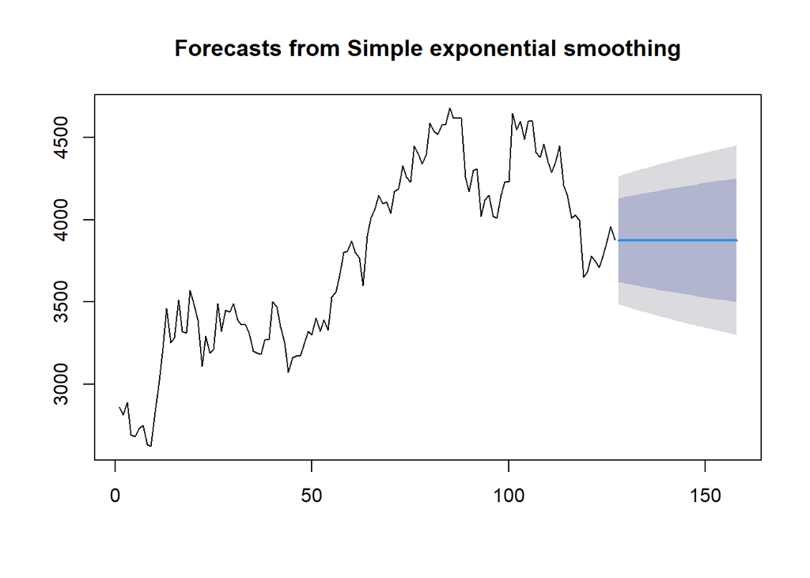

```r
#Cara 1 (fungsi ses)
ses.1 <- ses(train_data.ts, h = 31, alpha = 0.2)
plot(ses.1)
```

```r
ses.1
```

```
##     Point Forecast    Lo 80    Hi 80    Lo 95    Hi 95
## 128       3876.574 3622.420 4130.729 3487.879 4265.270
## 129       3876.574 3617.387 4135.762 3480.181 4272.967
## 130       3876.574 3612.450 4140.699 3472.630 4280.518
## 131       3876.574 3607.603 4145.546 3465.218 4287.931
## 132       3876.574 3602.842 4150.307 3457.937 4295.212
## 133       3876.574 3598.162 4154.986 3450.780 4302.369
## 134       3876.574 3593.560 4159.589 3443.742 4309.407
## 135       3876.574 3589.032 4164.117 3436.816 4316.333
## 136       3876.574 3584.573 4168.575 3429.998 4323.151
## 137       3876.574 3580.182 4172.967 3423.282 4329.867
## 138       3876.574 3575.855 4177.294 3416.664 4336.485
## 139       3876.574 3571.589 4181.559 3410.140 4343.009
## 140       3876.574 3567.383 4185.766 3403.706 4349.443
## 141       3876.574 3563.232 4189.917 3397.359 4355.790
```

[output cut: 17 more lines]

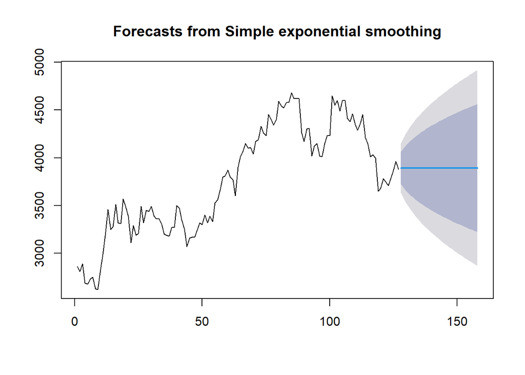

```r
ses.2<- ses(train_data.ts, h = 31, alpha = 0.7)
plot(ses.2)
```

```r
ses.2
```

```
##     Point Forecast    Lo 80    Hi 80    Lo 95    Hi 95
## 128       3893.005 3724.133 4061.878 3634.738 4151.273
## 129       3893.005 3686.871 4099.140 3577.749 4208.261
## 130       3893.005 3655.381 4130.630 3529.590 4256.420
## 131       3893.005 3627.602 4158.409 3487.106 4298.905
## 132       3893.005 3602.467 4183.544 3448.665 4337.346
## 133       3893.005 3579.339 4206.672 3413.294 4372.716
## 134       3893.005 3557.804 4228.207 3380.359 4405.652
## 135       3893.005 3537.571 4248.440 3349.415 4436.596
## 136       3893.005 3518.429 4267.582 3320.140 4465.871
## 137       3893.005 3500.219 4285.792 3292.290 4493.721
## 138       3893.005 3482.816 4303.194 3265.675 4520.336
## 139       3893.005 3466.123 4319.888 3240.145 4545.866
## 140       3893.005 3450.058 4335.953 3215.575 4570.435
## 141       3893.005 3434.555 4351.455 3191.867 4594.144
```

[output cut: 17 more lines]

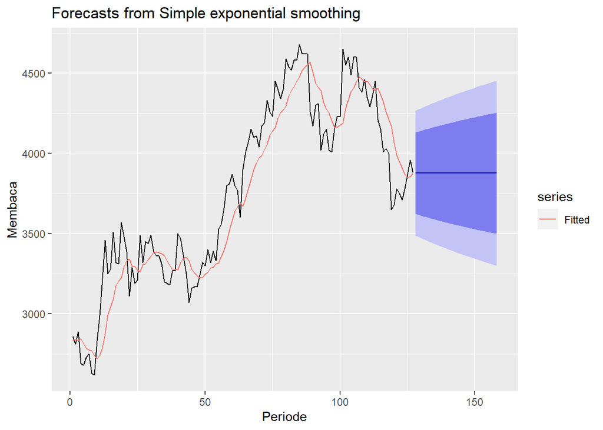

```r
autoplot(ses.1) +
  autolayer(fitted(ses.1), series="Fitted") +
  ylab("Membaca") + xlab("Periode")
```

Pada fungsi ses() , terdapat beberapa argumen yang umum digunakan, yaitu nilia y , gamma , beta , alpha , dan h .

Nilai y adalah nilai data deret waktu, gamma adalah parameter pemulusan untuk komponen musiman, beta adalah parameter pemulusan untuk tren, dan alpha adalah parameter pemulusan untuk stasioner, serta h adalah banyaknya periode yang akan diramalkan.

Kasus di atas merupakan contoh inisialisasi nilai parameter $\lambda$ dengan nilai alpha 0,2 dan 0,7 dan banyak periode data yang akan diramalkan adalah sebanyak 31 periode. Selanjutnya akan digunakan fungsi HoltWinters() dengan nilai inisialisasi parameter dan panjang periode peramalan yang sama dengan fungsi ses() .

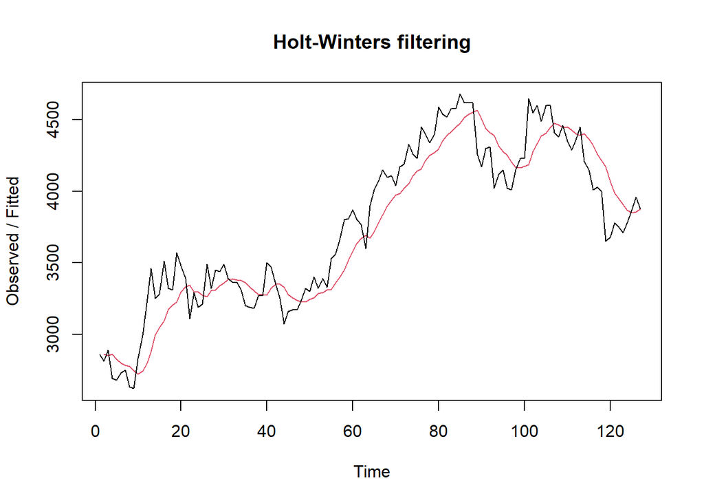

```r
#Cara 2 (fungsi Holtwinter)
ses1<- HoltWinters(train_data.ts, gamma = FALSE, beta = FALSE, alpha = 0.2)
plot(ses1)
```

```r
#ramalan
ramalan1<- forecast(ses1, h=31)
ramalan1
```

```
##     Point Forecast    Lo 80    Hi 80    Lo 95    Hi 95
## 128       3876.574 3627.730 4125.419 3495.999 4257.149
## 129       3876.574 3622.802 4130.347 3488.463 4264.686
## 130       3876.574 3617.968 4135.181 3481.069 4272.080
## 131       3876.574 3613.222 4139.927 3473.812 4279.337
## 132       3876.574 3608.561 4144.588 3466.683 4286.466
## 133       3876.574 3603.979 4149.170 3459.675 4293.473
## 134       3876.574 3599.473 4153.676 3452.784 4300.365
## 135       3876.574 3595.039 4158.110 3446.003 4307.146
## 136       3876.574 3590.674 4162.475 3439.327 4313.822
## 137       3876.574 3586.374 4166.775 3432.752 4320.397
## 138       3876.574 3582.138 4171.011 3426.272 4326.877
## 139       3876.574 3577.961 4175.188 3419.884 4333.264
## 140       3876.574 3573.842 4179.307 3413.585 4339.564
## 141       3876.574 3569.778 4183.371 3407.370 4345.779
```

[output cut: 17 more lines]

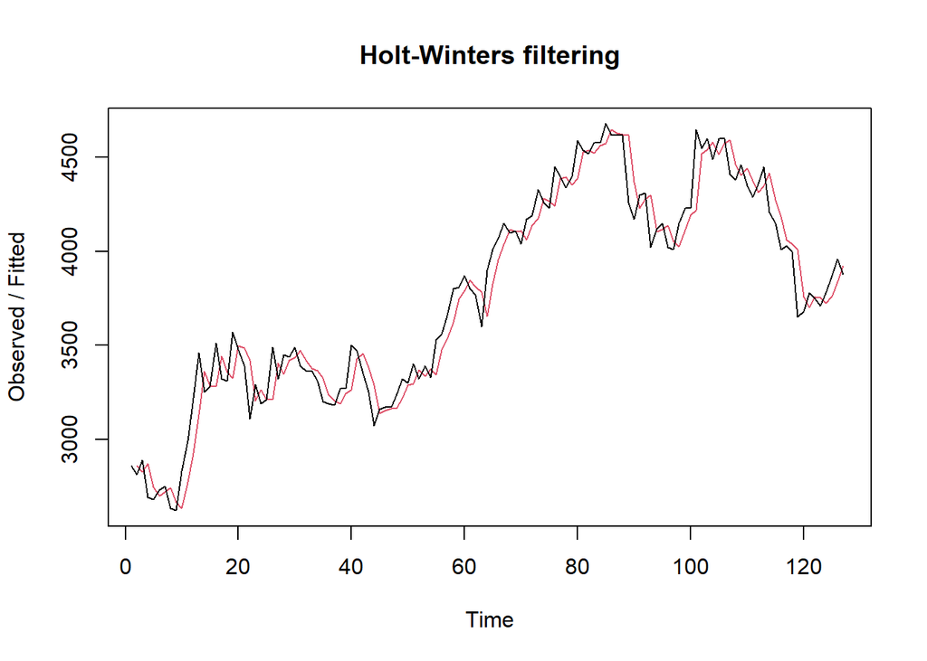

```r
ses2<- HoltWinters(train_data.ts, gamma = FALSE, beta = FALSE, alpha = 0.7)
plot(ses2)
```

```r
#ramalan
ramalan2<- forecast(ses2, h=31)
ramalan2
```

```
##     Point Forecast    Lo 80    Hi 80    Lo 95    Hi 95
## 128       3893.005 3724.799 4061.211 3635.757 4150.254
## 129       3893.005 3687.684 4098.327 3578.993 4207.017
## 130       3893.005 3656.319 4129.692 3531.024 4254.986
## 131       3893.005 3628.649 4157.362 3488.707 4297.303
## 132       3893.005 3603.613 4182.398 3450.418 4335.593
## 133       3893.005 3580.577 4205.434 3415.187 4370.824
## 134       3893.005 3559.126 4226.885 3382.381 4403.630
## 135       3893.005 3538.973 4247.038 3351.559 4434.451
## 136       3893.005 3519.907 4266.104 3322.400 4463.611
## 137       3893.005 3501.768 4284.242 3294.660 4491.351
## 138       3893.005 3484.435 4301.576 3268.150 4517.860
## 139       3893.005 3467.807 4318.204 3242.720 4543.290
## 140       3893.005 3451.805 4334.205 3218.248 4567.762
## 141       3893.005 3436.364 4349.646 3194.633 4591.378
```

[output cut: 17 more lines]

Fungsi HoltWinters memiliki argumen yang sama dengan fungsi ses() . Argumen-argumen kedua fungsi dapat dilihat lebih lanjut dengan ?ses() atau ?HoltWinters .

Nilai parameter $\alpha$ dari kedua fungsi dapat dioptimalkan menyesuaikan dari error-nya paling minimumnya. Caranya adalah dengan membuat parameter $\alpha =$ NULL .

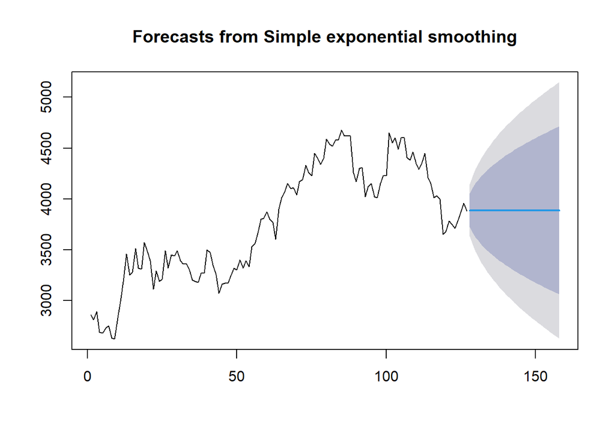

```r
#SES
ses.opt <- ses(train_data.ts, h = 31, alpha = NULL)
plot(ses.opt)
```

```r
ses.opt
```

```
##     Point Forecast    Lo 80    Hi 80    Lo 95    Hi 95
## 128       3887.551 3721.922 4053.181 3634.243 4140.860
## 129       3887.551 3665.766 4109.337 3548.360 4226.743
## 130       3887.551 3621.197 4153.906 3480.197 4294.905
## 131       3887.551 3583.084 4192.019 3421.908 4353.194
## 132       3887.551 3549.237 4225.865 3370.145 4404.958
## 133       3887.551 3518.482 4256.621 3323.109 4451.994
## 134       3887.551 3490.100 4285.003 3279.701 4495.401
## 135       3887.551 3463.613 4311.490 3239.194 4535.909
## 136       3887.551 3438.687 4336.416 3201.072 4574.031
## 137       3887.551 3415.074 4360.029 3164.959 4610.144
## 138       3887.551 3392.586 4382.517 3130.567 4644.536
## 139       3887.551 3371.076 4404.027 3097.670 4677.433
## 140       3887.551 3350.427 4424.676 3066.090 4709.012
## 141       3887.551 3330.543 4444.560 3035.680 4739.423
```

[output cut: 17 more lines]

```r
#Lamda Optimum Holt Winter
sesopt<- HoltWinters(train_data.ts, gamma = FALSE, beta = FALSE,alpha = NULL)
sesopt
```

```
## Holt-Winters exponential smoothing without trend and without seasonal component.
##
## Call:
## HoltWinters(x = train_data.ts, alpha = NULL, beta = FALSE, gamma = FALSE)
##
## Smoothing parameters:
##  alpha: 0.8906617
##  beta : FALSE
##  gamma: FALSE
##
## Coefficients:
##       [,1]
## a 3887.544
```

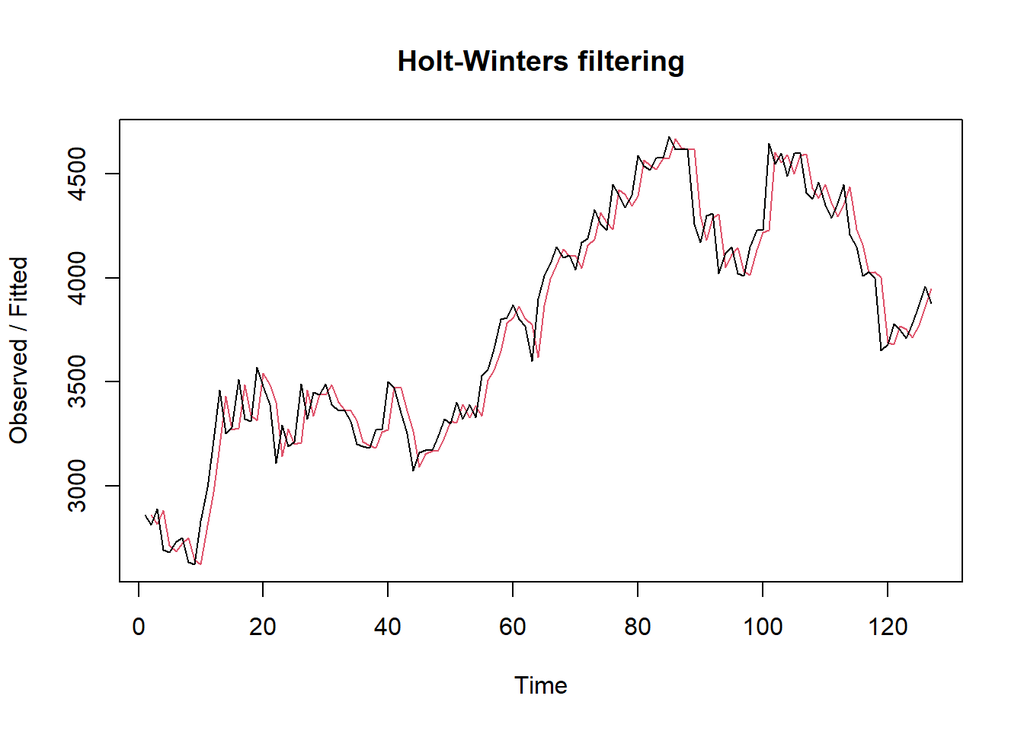

```r
plot(sesopt)
```

```r
#ramalan
ramalanopt<- forecast(sesopt, h=31)
ramalanopt
```

```
##     Point Forecast    Lo 80    Hi 80    Lo 95    Hi 95
## 128       3887.544 3722.333 4052.755 3634.876 4140.212
## 129       3887.544 3666.305 4108.783 3549.188 4225.900
## 130       3887.544 3621.839 4153.249 3481.184 4293.904
## 131       3887.544 3583.815 4191.273 3423.031 4352.057
## 132       3887.544 3550.048 4225.040 3371.389 4403.699
## 133       3887.544 3519.365 4255.723 3324.463 4450.625
## 134       3887.544 3491.050 4284.038 3281.158 4493.930
## 135       3887.544 3464.626 4310.463 3240.746 4534.342
## 136       3887.544 3439.758 4335.330 3202.715 4572.373
## 137       3887.544 3416.201 4358.887 3166.687 4608.401
## 138       3887.544 3393.766 4381.322 3132.376 4642.712
## 139       3887.544 3372.308 4402.781 3099.558 4675.530
## 140       3887.544 3351.707 4423.381 3068.053 4707.036
## 141       3887.544 3331.871 4443.218 3037.715 4737.374
```

[output cut: 17 more lines]

Setelah dilakukan peramalan, akan dilakukan perhitungan keakuratan hasil peramalan. Perhitungan akurasi ini dilakukan baik pada data latih dan data uji.

Akurasi Data Latih

Perhitungan akurasi data dapat dilakukan dengan cara langsung maupun manual. Secara langsung, nilai akurasi dapat diambil dari objek yang tersimpan pada hasil SES, yaitu sum of squared errors (SSE). Nilai akurasi lain dapat dihitung pula dari nilai SSE tersebut.

```r
#Keakuratan Metode
#Pada data training
SSE1<-ses1$SSE
MSE1<-ses1$SSE/length(train_data.ts)
RMSE1<-sqrt(MSE1)

akurasi1 <- matrix(c(SSE1,MSE1,RMSE1))
row.names(akurasi1)<- c("SSE", "MSE", "RMSE")
colnames(akurasi1) <- c("Akurasi lamda=0.2")
akurasi1
```

```
##      Akurasi lamda=0.2
## SSE       4918010.1867
## MSE         38724.4897
## RMSE          196.7854
```

```r
SSE2<-ses2$SSE
MSE2<-ses2$SSE/length(train_data.ts)
RMSE2<-sqrt(MSE2)

akurasi2 <- matrix(c(SSE2,MSE2,RMSE2))
row.names(akurasi2)<- c("SSE", "MSE", "RMSE")
colnames(akurasi2) <- c("Akurasi lamda=0.7")
akurasi2
```

```
##      Akurasi lamda=0.7
## SSE       2170662.2445
## MSE         17091.8287
## RMSE          130.7357
```

```r
#Cara Manual
fitted1<-ramalan1$fitted
sisaan1<-ramalan1$residuals
head(sisaan1)
```

```
## Time Series:
## Start = 1
## End = 6
## Frequency = 1
## [1]      NA  -50.00   40.00 -168.00 -144.40  -65.52
```

```r
resid1<-training_data$Close-ramalan1$fitted
head(resid1)
```

```
## Time Series:
## Start = 1
## End = 6
## Frequency = 1
## [1]      NA  -50.00   40.00 -168.00 -144.40  -65.52
```

```r
#Cara Manual
SSE.1=sum(sisaan1[2:length(train_data.ts)]^2)
SSE.1
```

```
## [1] 4918010
```

```r
MSE.1 = SSE.1/length(train_data.ts)
MSE.1
```

```
## [1] 38724.49
```

```r
MAPE.1 = sum(abs(sisaan1[2:length(train_data.ts)]/train_data.ts[2:length(train_data.ts)])*
               100)/length(train_data.ts)
MAPE.1
```

```
## [1] 4.263199
```

```r
akurasi.1 <- matrix(c(SSE.1,MSE.1,MAPE.1))
row.names(akurasi.1)<- c("SSE", "MSE", "MAPE")
colnames(akurasi.1) <- c("Akurasi lamda=0.2")
akurasi.1
```

```
##      Akurasi lamda=0.2
## SSE       4.918010e+06
## MSE       3.872449e+04
## MAPE      4.263199e+00
```

```r
fitted2<-ramalan2$fitted
sisaan2<-ramalan2$residuals
head(sisaan2)
```

```
## Time Series:
## Start = 1
## End = 6
## Frequency = 1
## [1]       NA  -50.000   65.000 -180.500  -64.150   30.755
```

```r
resid2<-training_data$Close-ramalan2$fitted
head(resid2)
```

```
## Time Series:
## Start = 1
## End = 6
## Frequency = 1
## [1]       NA  -50.000   65.000 -180.500  -64.150   30.755
```

```r
SSE.2=sum(sisaan2[2:length(train_data.ts)]^2)
SSE.2
```

```
## [1] 2170662
```

```r
MSE.2 = SSE.2/length(train_data.ts)
MSE.2
```

```
## [1] 17091.83
```

```r
MAPE.2 = sum(abs(sisaan2[2:length(train_data.ts)]/train_data.ts[2:length(train_data.ts)])*
               100)/length(train_data.ts)
MAPE.2
```

```
## [1] 2.656759
```

```r
akurasi.2 <- matrix(c(SSE.2,MSE.2,MAPE.2))
row.names(akurasi.2)<- c("SSE", "MSE", "MAPE")
colnames(akurasi.2) <- c("Akurasi lamda=0.7")
akurasi.2
```

```
##      Akurasi lamda=0.7
## SSE       2.170662e+06
## MSE       1.709183e+04
## MAPE      2.656759e+00
```

Berdasarkan nilai SSE, MSE, RMSE, dan MAPE di antara kedua parameter, nilai parameter $\lambda=0,7$ menghasilkan akurasi yang lebih baik dibanding $\lambda=0,2$ . Hal ini dilihat dari nilai masing-masing ukuran akurasi yang lebih kecil. Berdasarkan nilai MAPE-nya, hasil ini dapat dikategorikan sebagai peramalan sangat baik.

Akurasi Data Uji

Akurasi data uji dapat dihitung dengan cara yang hampir sama dengan perhitungan akurasi data latih

```r
selisih1<-ramalan1$mean-testing_data$Close
SSEtesting1<-sum(selisih1^2)
MSEtesting1<-SSEtesting1/length(testing_data)

selisih2<-ramalan2$mean-testing_data$Close
SSEtesting2<-sum(selisih2^2)
MSEtesting2<-SSEtesting2/length(testing_data)

selisihopt<-ramalanopt$mean-testing_data$Close
SSEtestingopt<-sum(selisihopt^2)
MSEtestingopt<-SSEtestingopt/length(testing_data)

akurasitesting1 <- matrix(c(SSEtesting1,SSEtesting2,SSEtestingopt))
row.names(akurasitesting1)<- c("SSE1", "SSE2", "SSEopt")
akurasitesting1
```

```
##           [,1]
## SSE1   1287484
## SSE2   1199693
## SSEopt 1227015
```

```r
akurasitesting2 <- matrix(c(MSEtesting1,MSEtesting2,MSEtestingopt))
row.names(akurasitesting2)<- c("MSE1", "MSE2", "MSEopt")
akurasitesting2
```

```
##            [,1]
## MSE1   643742.0
## MSE2   599846.6
## MSEopt 613507.7
```

Selain dengan cara di atas, perhitungan nilai akurasi dapat menggunakan fungsi accuracy() dari package forecast . Penggunaannya yaitu dengan menuliskan accuracy(hasil ramalan, kondisi aktual) . Contohnya adalah sebagai berikut.

```r
#cara lain
accuracy(ramalanopt,testing_data$Close)
```

```
##                    ME     RMSE       MAE       MPE     MAPE      MASE
## Training set  9.15624 128.7281  96.71707 0.2046558 2.629660 0.9939927
## Test set     83.42360 198.9501 168.29079 1.8987440 4.170093 1.7295791
##                       ACF1
## Training set -0.0007207001
## Test set                NA
```